# Preprocessing Telley et al, 2019 dataset

Matthieu Moreau[^1]

30 novembre, 2020

# Load libraries

```r
# Load library
library(Seurat)
library(dplyr)
library(patchwork)

#Set ggplot theme as classic
theme_set(theme_classic())
```

To define temporally versus spatially regulated genes, we used **dorso-pallial apical progenitors** scRNAseq data obtained by facs sorting 1H after flashtag injection from :

> Telley L, Agirman G *et al.* **Temporal patterning of apical progenitors and their daughter neurons in the developing neocortex.** [Science 2019 May 10;364(6440).](https://science.sciencemag.org/content/364/6440/eaav2522.long)

# Extract and filter apical progenitors from Telley et al 2019

## Fetch Telley et al 2019 dataset from GEO

```bash
mkdir Telley2019data

wget https://ftp.ncbi.nlm.nih.gov/geo/series/GSE118nnn/GSE118953/suppl/GSE118953_raw_count.tsv.gz -P ./Telley2019data
gunzip ./Telley2019data/GSE118953_raw_count.tsv.gz
```

[output not shown]

[output cut: 326 more lines]

[output not shown]

## Extract 1H flashtag cells and perform QC filtering

```r
# Load the raw count matrix and extract 1H flashtagged cells
data <- read.table("./Telley2019data/GSE118953_raw_count.tsv", header = T, row.names = 1)
APcells <- grep("1H", colnames(data), value = T)

data <- data[,APcells]

# Initialize the Seurat object
Raw.data <- CreateSeuratObject(raw.data = data,
                               min.cells = 3,
                               min.genes = 800,
                               project = "Telley2019")

Raw.data@meta.data$Barcodes <- rownames(Raw.data@meta.data)

rm(data,APcells)
```

## Calculate percentage of mt and ribo counts

```r
# Percent of mitochondrial counts
mito.genes <- grep(pattern = "^mt-", x = rownames(x = Raw.data@data), value = TRUE)
percent.mito <- Matrix::colSums(Raw.data@raw.data[mito.genes, ])/Matrix::colSums(Raw.data@raw.data)
Raw.data <- AddMetaData(object = Raw.data, metadata = percent.mito, col.name = "percent.mito")

# Percent of mitochondrial ribosomal
ribo.genes <- grep(pattern = "(^Rpl|^Rps|^Mrp)", x = rownames(x = Raw.data@data), value = TRUE)
percent.ribo <- Matrix::colSums(Raw.data@raw.data[ribo.genes, ])/Matrix::colSums(Raw.data@raw.data)
Raw.data <- AddMetaData(object = Raw.data, metadata = percent.ribo, col.name = "percent.ribo")
```

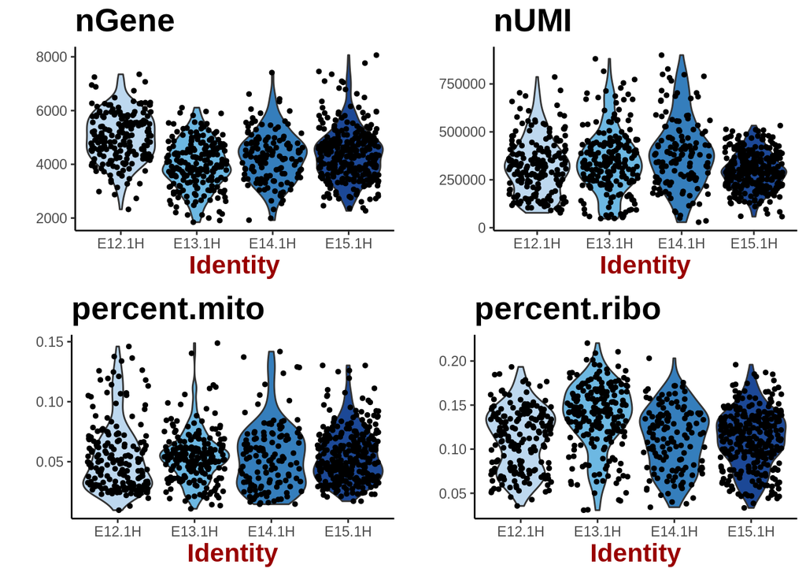

```r
# Violin plot
VlnPlot(object = Raw.data, features.plot = c("nGene","nUMI", "percent.mito", "percent.ribo"),
        nCol = 2, cols.use = c("#bdd8ef", "#6db8e2", "#357ebc", "#1c4896"))
```

According to authors’ informations given in the [supplementary materials](https://science.sciencemag.org/content/sci/suppl/2019/05/08/364.6440.eaav2522.DC1/aav2522_Telley_SM.pdf), this dataset contains only QC passed cells.

> “Cells expressing < 1000 genes or > 17% of mitochondrial 8 genes were excluded. After this step, 2,756 cells remained for analysis (FT +1 h: **E12: 189** cells, **E13: 207**, **E14: 134**, **E15: 301** […]”

```r
table(Raw.data@ident)
```

```
##
## E12.1H E13.1H E14.1H E15.1H
##    189    207    134    301
```

## Filter genes, normalize counts and scale expression matrix

```r
# Filter genes expressed by less than 3 cells
num.cells <- Matrix::rowSums(Raw.data@data > 0)
genes.use <- names(x = num.cells[which(x = num.cells >= 10)])
Raw.data@raw.data <- Raw.data@raw.data[genes.use, ]
Raw.data@data <- Raw.data@data[genes.use, ]
```

```r
# logNormalized the gene expression matrix
Raw.data <- NormalizeData(object = Raw.data,
                         normalization.method = "LogNormalize",
                         scale.factor = round(median(Raw.data@meta.data$nUMI)),
                         display.progress = F)
```

```r
# Assign Cell-Cycle Scores
s.genes <- c("Mcm5", "Pcna", "Tym5", "Fen1", "Mcm2", "Mcm4", "Rrm1", "Ung", "Gins2", "Mcm6", "Cdca7", "Dtl", "Prim1", "Uhrf1", "Mlf1ip", "Hells", "Rfc2", "Rap2", "Nasp", "Rad51ap1", "Gmnn", "Wdr76", "Slbp", "Ccne2", "Ubr7", "Pold3", "Msh2", "Atad2", "Rad51", "Rrm2", "Cdc45", "Cdc6", "Exo1", "Tipin", "Dscc1", "Blm", " Casp8ap2", "Usp1", "Clspn", "Pola1", "Chaf1b", "Brip1", "E2f8")
g2m.genes <- c("Hmgb2", "Ddk1","Nusap1", "Ube2c", "Birc5", "Tpx2", "Top2a", "Ndc80", "Cks2", "Nuf2", "Cks1b", "Mki67", "Tmpo", " Cenpk", "Tacc3", "Fam64a", "Smc4", "Ccnb2", "Ckap2l", "Ckap2", "Aurkb", "Bub1", "Kif11", "Anp32e", "Tubb4b", "Gtse1", "kif20b", "Hjurp", "Cdca3", "Hn1", "Cdc20", "Ttk", "Cdc25c", "kif2c", "Rangap1", "Ncapd2", "Dlgap5", "Cdca2", "Cdca8", "Ect2", "Kif23", "Hmmr", "Aurka", "Psrc1", "Anln", "Lbr", "Ckap5", "Cenpe", "Ctcf", "Nek2", "G2e3", "Gas2l3", "Cbx5", "Cenpa")

Raw.data <- CellCycleScoring(object = Raw.data,
                            s.genes = s.genes,
                            g2m.genes = g2m.genes,
                            set.ident = F)
```

```r
# We decide to regress out the effect cell cycle
Raw.data@meta.data$CC.Difference <- Raw.data@meta.data$S.Score - Raw.data@meta.data$G2M.Score
Raw.data <- ScaleData(object = Raw.data,
                     vars.to.regress = c("CC.Difference","percent.mito","nGene", "nUMI"),
                     display.progress = F)
```

# Explore transcriptional diversity among the progenitors

```r
# Find most variable genes
Raw.data  <- FindVariableGenes(object = Raw.data,
                               mean.function = ExpMean,
                               dispersion.function = LogVMR,
                               x.low.cutoff = 0.0125,
                               x.high.cutoff = 3,
                              y.cutoff = 1, do.plot = F)

length(Raw.data@var.genes)
```

```
## [1] 1371
```

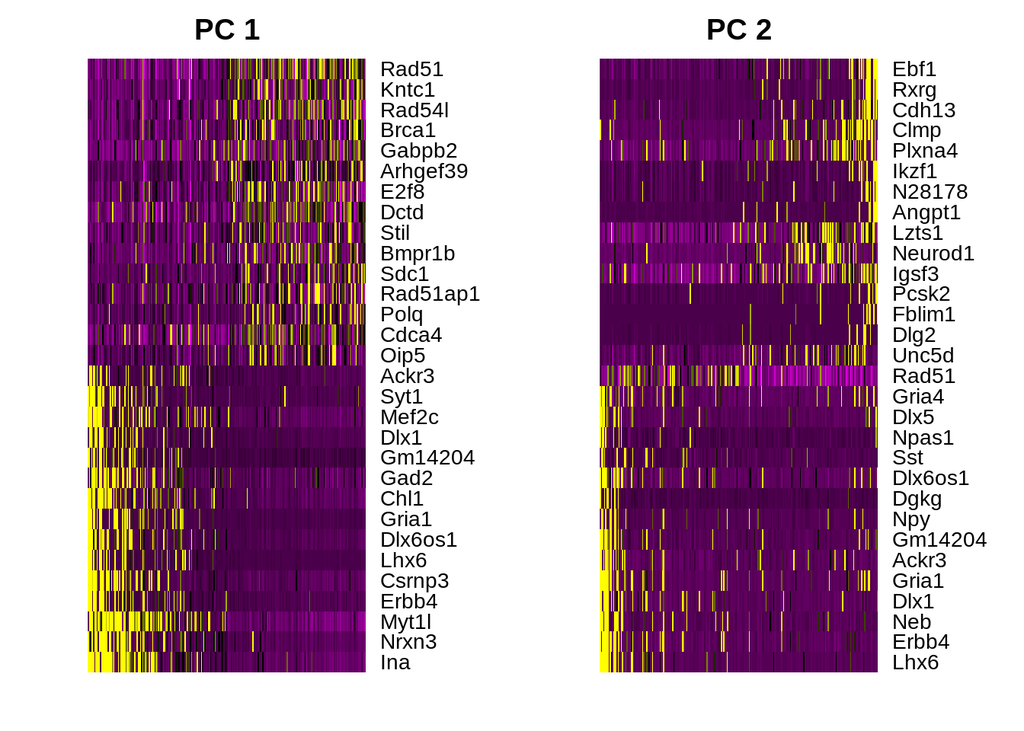

```r
# Run PCA
Raw.data <- RunPCA(object = Raw.data,
                  pcs.compute = 15,
                  do.print =F)

PCHeatmap(object = Raw.data, pc.use = 1:2, cells.use = 250, do.balanced = TRUE, label.columns = FALSE)
```

```r
# Perform broad graph-based clustering
Raw.data <- FindClusters(Raw.data,
                        reduction.type = "pca",
                        dims.use = 1:10,
                        k.param = 20,
                        algorithm = 1,
                        resolution = 0.6,
                        print.output = F,
                        random.seed =1234)

Raw.data <- RunUMAP(Raw.data, dims.use = 1:10, n_neighbors = 20, max.dim = 2)
```

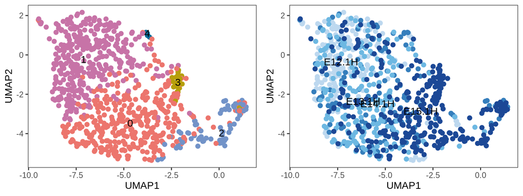

```r
p1 <- DimPlot(Raw.data,
              reduction.use = "umap",
              dim.1 = 1,
              dim.2 = 2,
              do.label=T,
              label.size = 4,
              no.legend = T,
              pt.size = 2,
              cols.use = c("#ec756d", "#c773a7", "#7293c8", "#b79f0b", "#046c9a"),
              do.return = T)

p2 <- DimPlot(Raw.data,
              reduction.use = "umap",
              group.by ="orig.ident",
              dim.1 = 1,
              dim.2 = 2,
              do.label=T,
              label.size = 4,
              no.legend = T,
              pt.size = 2,
              cols.use = c("#bdd8ef", "#6db8e2", "#357ebc", "#1c4896"),
              do.return = T)

p1 + p2
```

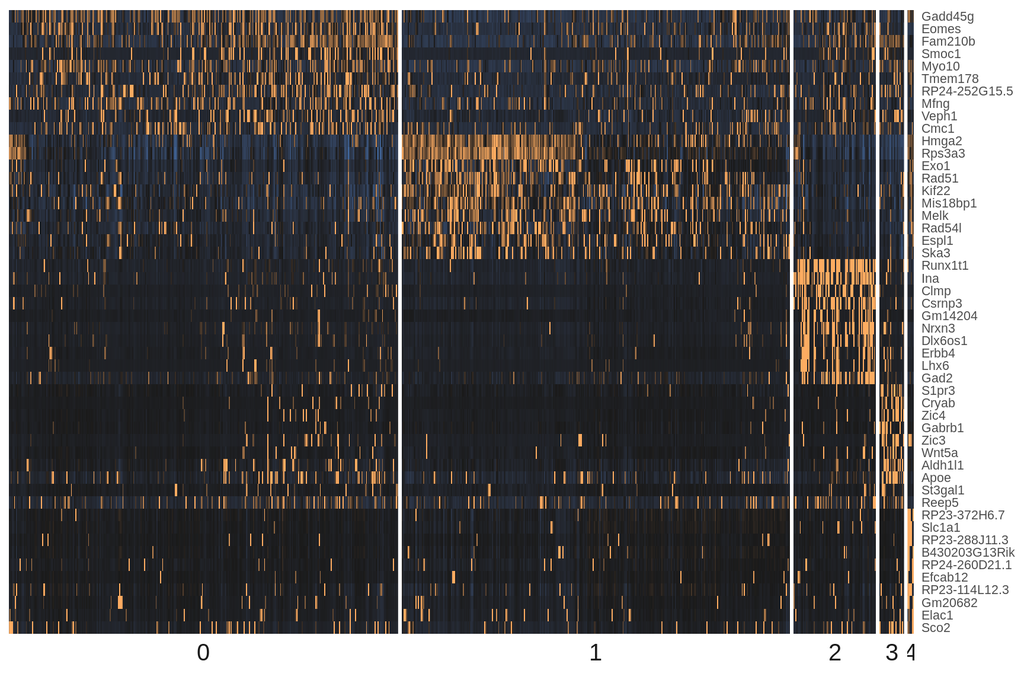

```r
# Find all markers between clusters
Allmarkers <- FindAllMarkers(object = Raw.data,
                             min.pct = 0.3,
                             logfc.threshold = 0.6,
                             print.bar = F,
                             only.pos = T)

Topmarkers <- Allmarkers %>% group_by(cluster) %>% top_n(10, avg_logFC)
DoHeatmap(object = Raw.data,
          genes.use = Topmarkers$gene,
          use.scaled = TRUE,
          slim.col.label = TRUE,
          remove.key = T,
          col.low = "#4575b4",
          col.mid = "#1a1a1a",
          col.high = "#fdac61",
          cex.row =8)
```

- Cluster 2 cells express *Gad1/2* and *Lhx6* and might therefore correspond to cells contaminated with GABAergic neurons transcripts.
- Cluster 3 gathers only E15 cells expressing *Wnt5a*, thus likely to be from a medial pallial origin.
- Cluster 4 contains 6 cells with unclear transcriptional signature

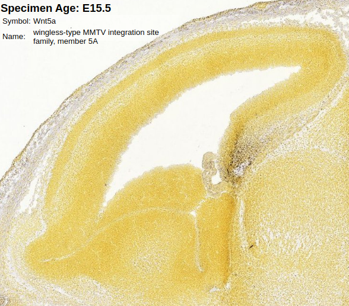

We excluded these 3 clusters for downstream analysis

# Retain only dorso-pallial derived AP form the dataset

```r
Filtered.data <- SubsetData(Raw.data,
                            ident.use = c(0,1),
                            subset.raw = T,
                            do.clean = F)

table(Filtered.data@meta.data$orig.ident)
```

```
##
## E12.1H E13.1H E14.1H E15.1H
##    178    202    124    221
```

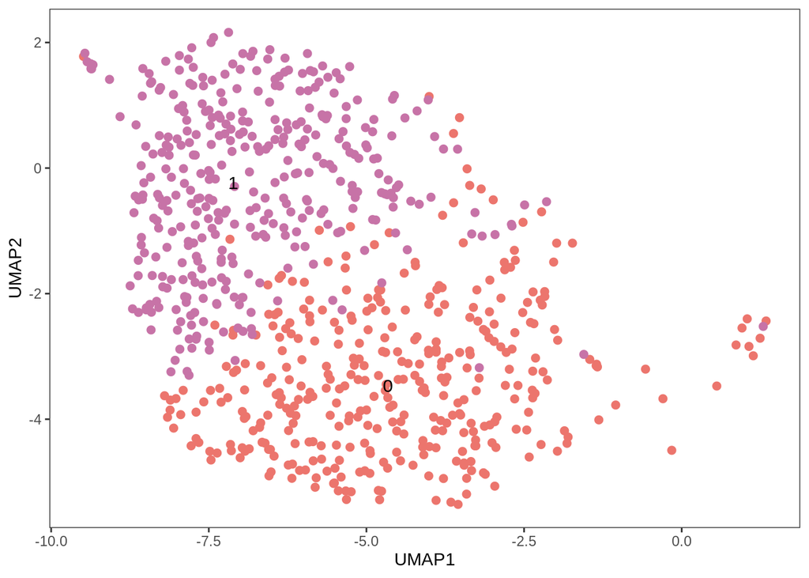

```r
DimPlot(Filtered.data,
        reduction.use = "umap",
        dim.1 = 1,
        dim.2 = 2,
        do.label=T,
        label.size = 4,
        no.legend = T,
        pt.size = 2,
        cols.use = c("#ec756d", "#c773a7", "#7293c8", "#b79f0b", "#046c9a"),
        do.return = T)
```

```r
# Filter genes expressed by less than 3 cells
num.cells <- Matrix::rowSums(Filtered.data@data > 0)
genes.use <- names(x = num.cells[which(x = num.cells >= 10)])
Filtered.data@raw.data <- Filtered.data@raw.data[genes.use, ]
Filtered.data@data <- Filtered.data@data[genes.use, ]
```

```r
# logNormalized the gene expression matrix
Filtered.data <- NormalizeData(object = Filtered.data,
                               normalization.method = "LogNormalize",
                               scale.factor = round(median(Filtered.data@meta.data$nUMI)),
                               display.progress = F)
```

```r
Filtered.data <- ScaleData(object = Filtered.data,
                           vars.to.regress = c("CC.Difference","percent.mito","nGene", "nUMI"),
                           display.progress = F)
```

```r
saveRDS(Filtered.data, "./Telley2019data/Telley2019.RDS")
```

# Session Info

```r
#date
format(Sys.time(), "%d %B, %Y, %H,%M")
```

```
## [1] "30 novembre, 2020, 10,59"
```

[^1]: Institute of Psychiatry and Neuroscience of Paris, INSERM U1266, 75014, Paris, France, matthieu.moreau@inserm.fr